# Model-based Analysis of Ubiquitin Proteasome System

Collin Tokheim, Wubing Zhang, Jun Ge, X. Shirley Liu

Dana-Farber Cancer Institute

24 March 2020

#### Abstract

Advances in proteomic profiling have enabled the study of protein regulation and degradation in diseases such as cancer. However, there are major computational challenges, such as how to perform quality control (QC) and normalization, how to identify differential protein abundance at multiple-levels of resolution (e.g. protein complexes), and how to integrate data with other omic technologies. Here, we developed a computational analysis pipeline Model-based Analysis of the Ubiquitin-Proteasome System using R (rMAUPS), which performs computational analysis of proteomics data efficiently and effectively. rMAUPS comprises four significant modules, including quality control (QC), imputation, differential analysis, and integrative analysis.

#### Package

rMAUPS - 0.1.1

# 1 Install required packages

Installing the package in a fresh R environment may take a long time. It may fail because of some issues. You can check the possible issues and solutions from https://github.com/WubingZhang/rMAUPS/issues/3, or post a new issue there.

## 1.1 Installation using R

One of the dependencies require `libnetcdf`, you can install it using `conda install -c anaconda libnetcdf` in the bash command line.

```bash
$ conda install -c anaconda libnetcdf
```

Then you can install all the required R packages in R.

```r
install.packages(c("devtools", "BiocManager"), repos = "https://cloud.r-project.org")
BiocManager::install(c("GSVA", "DESeq2", "limma", "impute", "biomaRt", "GO.db", "msmsTests", "BiocStyle"))
devtools::install_github("WubingZhang/rMAUPS")
```

## 1.2 Installation using bash command line

```bash
$ conda install -c anaconda libnetcdf
$ conda install -c conda-forge r-devtools r-biocmanager r-ggpubr r-metap
$ Rscript -e 'BiocManager::install(c("GSVA", "DESeq2", "limma", "impute", "biomaRt", "GO.db", "msmsTests", "BiocStyle"))'
$ Rscript -e 'devtools::install_github("WubingZhang/rMAUPS")'
```

## 1.3 load required packages

The environment should be OK if you can load the required packages successfully.

```r
library(ggplot2)
library(rMAUPS)
```

# 2 LC-MS/MS dataset

The rMAUPS package includes two real LC-MS/MS data files ending with “export_proteins.txt”, which are exported from the Proteome Discoverer software. Here, we will take the two datasets as an example to describe how to analyze the data using the rMAUPS pipeline. Before running the pipeline, the data can be preprocessed into a tidy format using the function `normalizeProteomeDiscoverer`.

- List the two files as follow:

```r
datapath = system.file("extdata", package = "rMAUPS")
list.files(datapath, pattern = "export_proteins")
```

```
## [1] "experiment1_export_proteins.txt" "experiment2_export_proteins.txt"
```

- Preprocess all the datasets in the folder

```r
normalizeProteomeDiscoverer(datapath, output = "./", log2 = TRUE)
```

```
## Mar-24-2020 14:31:28 Processing /Library/Frameworks/R.framework/Versions/3.5/Resources/library/rMAUPS/extdata/experiment1_export_proteins.txt
```

```
## Mar-24-2020 14:31:29 Processing /Library/Frameworks/R.framework/Versions/3.5/Resources/library/rMAUPS/extdata/experiment2_export_proteins.txt
```

```
## [1] TRUE
```

- Process one dataset

```r
normdata = normalizeProteomeDiscoverer(file.path(datapath, "experiment1_export_proteins.txt"), log2 = TRUE, return = TRUE)
```

```
## Mar-24-2020 14:31:29 Processing /Library/Frameworks/R.framework/Versions/3.5/Resources/library/rMAUPS/extdata/experiment1_export_proteins.txt
```

```r
head(normdata)
```

```
##         PSMs F1.126.DMSO F1.127N.DMSO F1.127C.DMSO F1.128N.MLN4924
## AHNAK   1411   7.2505030    7.6678385    7.6800153       7.4199202
## FLNB     557  -0.3907115   -0.1707519   -0.1218003      -0.1352324
## DYNC1H1  410   5.0411237    4.7732085    4.6884241       5.1122591
## AHNAK2   349   5.0226038    5.1310190    5.3911218       4.9934428
## FLNC     504   5.3129906    5.3637808    5.2985534       5.4937850
## SPTAN1   353  -2.3213765   -2.3777361   -2.1824982      -2.5368991
##         F1.128C.MLN4924 F1.129N.MLN4924 F1.129C.CSN5i.R F1.130N.CSN5i.R
## AHNAK         7.0438406       7.1233083       7.3832827      7.57337436
## FLNB         -0.4055006      -0.2957409      -0.1762043     -0.07383365
## DYNC1H1       6.0084579       5.3129985       5.2337983      4.91458815
## AHNAK2        4.6431495       4.8088745       5.0144311      5.24339380
## FLNC          5.2117384       5.3215400       5.4332368      5.43162251
## SPTAN1       -2.4802570      -2.3631797      -2.3115984     -2.31050604
##         F1.130C.CSN5i.R
## AHNAK         7.1545078
## FLNB         -0.2216058
## DYNC1H1       5.2747704
## AHNAK2        4.8052963
## FLNC          5.4902761
## SPTAN1       -2.4415415
```

# 3 Quick start

After preprocessing the datasets, you can run rMAUPS pipeline quickly. The pipeline requires a metadata, which configs the path to the datasets, list of samples and their experimental conditions, and design matrix of the comparisons.

## 3.1 Metadata configuration

rMAUPS includes a metadata as an example, you can read the file `metadata.csv` and check the format of the metadata.

```r
metadata = read.csv(file.path(datapath, "metadata.csv"))
head(metadata)
```

```
##                 Experiment          Sample Condition Comparison_MLN4924
## 1 experiment1_normdata.csv     F1.126.DMSO      DMSO                  0
## 2 experiment1_normdata.csv    F1.127N.DMSO      DMSO                  0
## 3 experiment1_normdata.csv    F1.127C.DMSO      DMSO                  0
## 4 experiment1_normdata.csv F1.128N.MLN4924   MLN4924                  1
## 5 experiment1_normdata.csv F1.128C.MLN4924   MLN4924                  1
## 6 experiment1_normdata.csv F1.129N.MLN4924   MLN4924                  1
##   Comparison_CSN5i
## 1                0
## 2                0
## 3                0
## 4               NA
## 5               NA
## 6               NA
```

## 3.2 Run the pipeline

After configuring the metadata, it’s ready to run the pipeline using one-line command.

```r
MAUPSr(metadata, outdir = "analysis/")
## Or
MAUPSr(system.file("extdata", "metadata.csv", package = "rMAUPS"), outdir = "analysis/")
```

To better display all the results, we developed a mini shiny app, which includes all the rMAUPS results in a webpage. You can open it by using function `view`.

```r
view(outdir = "analysis/")
```

Input the path to rMAUPS results, e.g. “analysis/” here, click `submit`, then all the figure results will be loaded on the webpage. It take seconds to load all the figures, please be patient after clicking `submit`.

# 4 Step-by-step analysis of proteomics

Besides the quick run of rMAUPS pipeline, you can also perform step-by-step analysis using functions in rMAUPS. You can perform quality control using the function `ProteomicsQC`, normalize the proteomics data using `normalizeProteomics`, impute the missing values using `imputeNA`, perform differetial analysis using `DEAnalyze`, and test the differential abundance of protein complexes or pathways using `DeComplex`.

## 4.1 Example dataset

To give an example about the quality control and imputation, we randomly assigned 10% values to be NA in the data.

```r
data = as.matrix(normdata[,-1])
meta = metadata[metadata$Experiment=="experiment1_normdata.csv", -1]
rownames(meta) = meta[,1]
simulated = data
idx = sample(1:length(simulated), round(0.1*length(simulated)))
simulated[idx] = NA
```

## 4.2 Data quality control

1. The distribution of protein abundances across samples.
2. The principal component analysis.
3. Pairwise correlation of proteins within the same complexes
4. The number of detected genes / missing values in each sample.

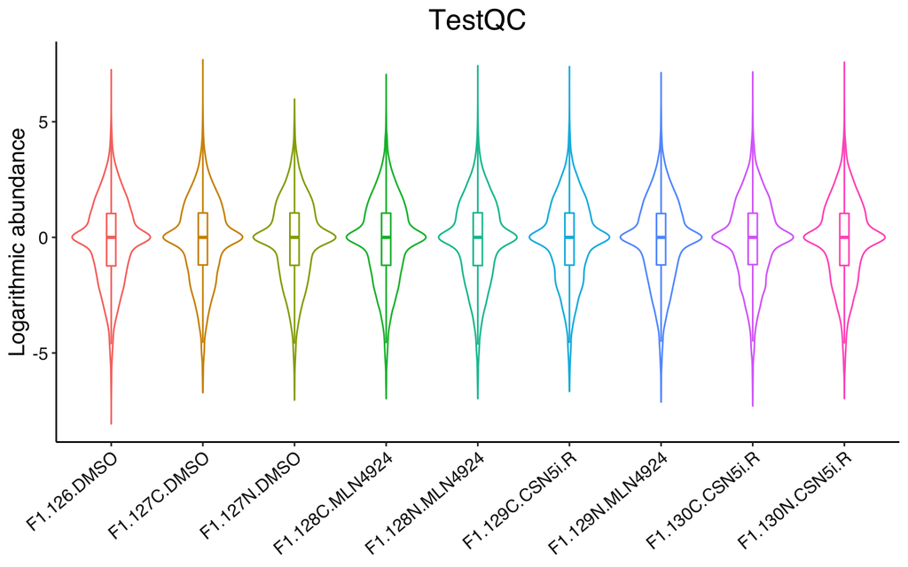

```r
qc = ProteomicsQC(simulated, condition = meta[colnames(data), 2], proj.name = "TestQC")
qc$p1
```

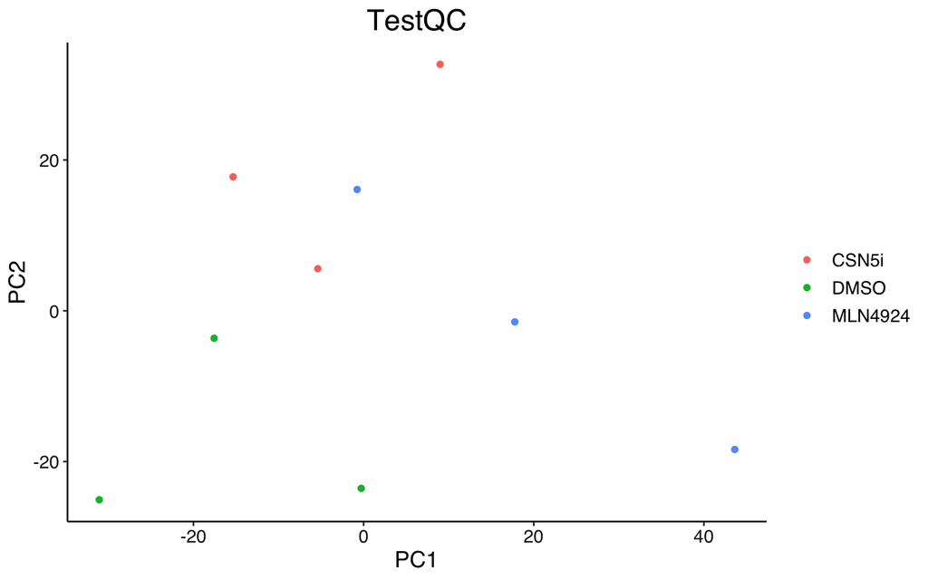

```r
qc$p2
```

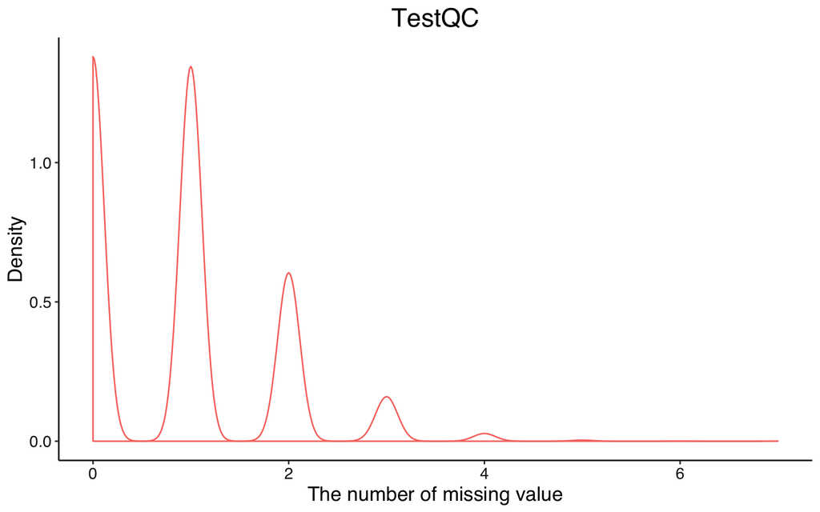

```r
qc$p4
```

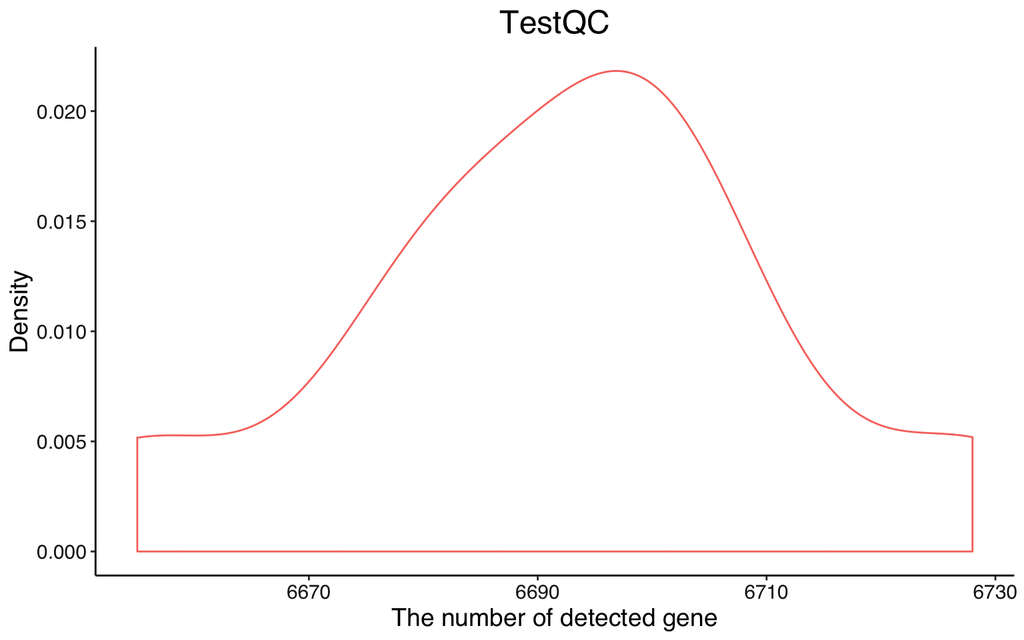

```r
qc$p5
```

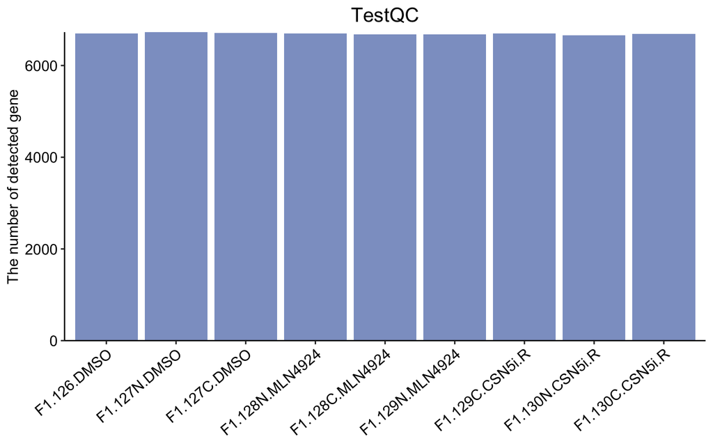

```r
qc$p6
```

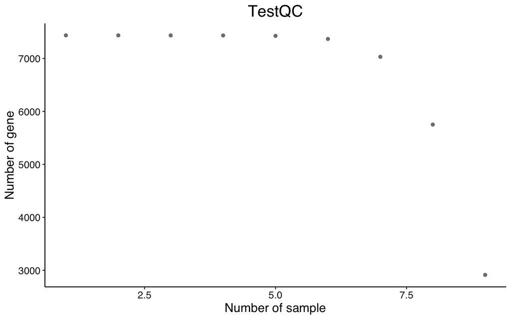

```r
qc$p7
```

## 4.3 Data normalization

rMAUPS provides a function, `normalizeProteomics`, to normalize proteomics data. You can easily normalize the data using multiple optional methods, such as median normalization, median ratio normalization, z-score normalization, quatile normalization and loess normalization.

```r
normalized = normalizeProteomics(simulated, norm = "median", log2 = FALSE)
```

## 4.4 Imputation

### 4.4.1 Imputation using KNN

```r
imputed = imputeNA(normalized)
```

```
## Cluster size 7436 broken into 4088 3348
## Done cluster 4088
## Done cluster 3348
```

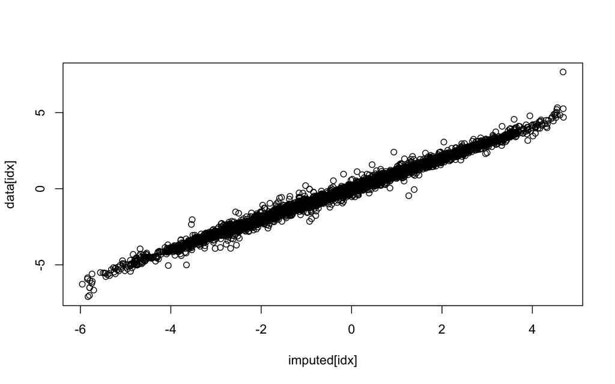

```r
plot(imputed[idx], data[idx])
```

After normalization and imputation, you can perform the quality control analysis again.

## 4.5 Differential expression analysis

rMAUPS provides a integrated function `DEAnalyze` to perform differential expression analysis for both RNA-seq data and proteomics data. For RNA-seq data, `type = "RNAseq", method = "DESeq2"` is recommended; for label-free proteomics, `type = "msms", method = "msms.edgeR"` is suggested; for isobaric labeling-based relative quantification of prpteomics, `type = "msms", method = "limma"` is preferred.

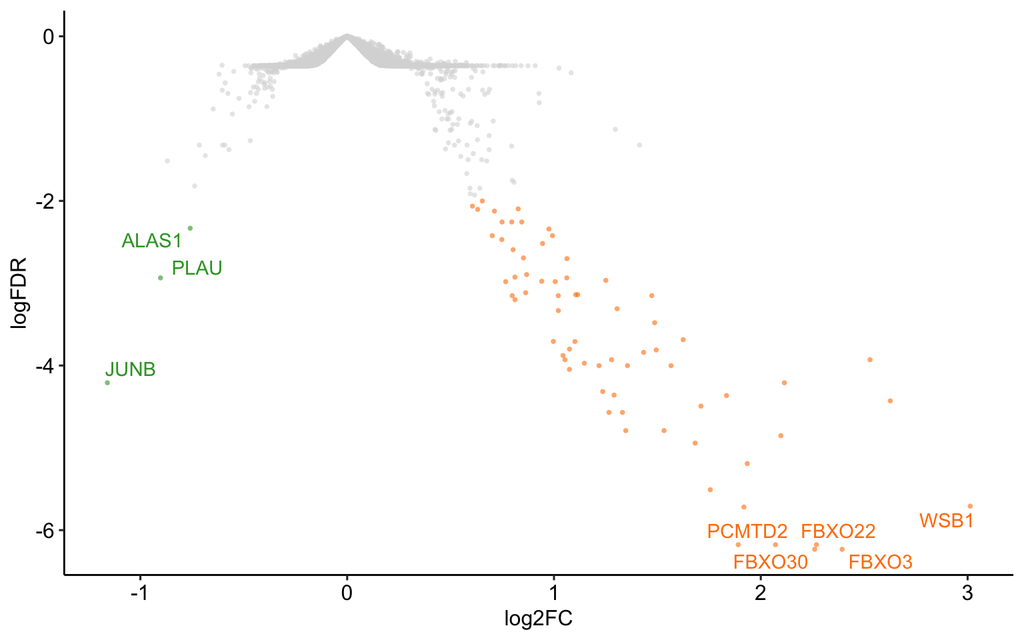

```r
deres = DEAnalyze(data, meta[,-1], type = "msms", method = "limma")
## Visualize the results
deres$logFDR = log10(deres$padj)
ScatterView(deres, x = "log2FC", y = "logFDR",
            x_cut = c(-0.5,0.5), y_cut = -2,
            groups = c("bottomleft", "bottomright"), top = 5)
```

## 4.6 Differential expression of pathways/complexes

For proteomics data analysis, the protein complex level analysis is informative. So we design a function DeComplex to combine the differential abundance of proteins into differential level of protein complexes or biological pathways.

```r
res = DeComplex(deres)
head(res$deComplex)
```

```
##                                           Description      Zscore     pvalue
## CORUM:1                            BCL6-HDAC4 complex -0.18722755 0.20399237
## CORUM:10                          Condensin I complex  0.16041965 0.21911134
## CORUM:100                               hNURF complex  0.37642869 0.05209979
## CORUM:1000                    TorsinA-TorsinB complex -0.09178932 0.44358194
## CORUM:1003 RC complex (Replication competent complex)  0.09704660 0.15012341
## CORUM:1004    RC complex during S-phase of cell cycle  0.16570509 0.15061947
##                 logP
## CORUM:1    0.6903861
## CORUM:10   0.6593351
## CORUM:100  1.2831641
## CORUM:1000 0.3530261
## CORUM:1003 0.8235516
## CORUM:1004 0.8221189
```

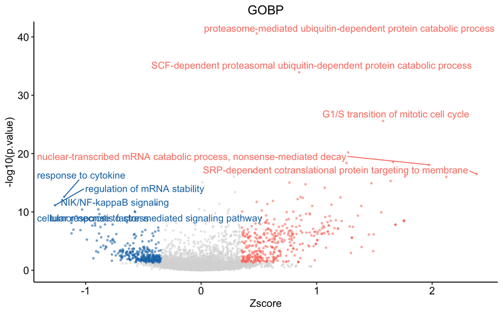

```r
res$gobp.p
```

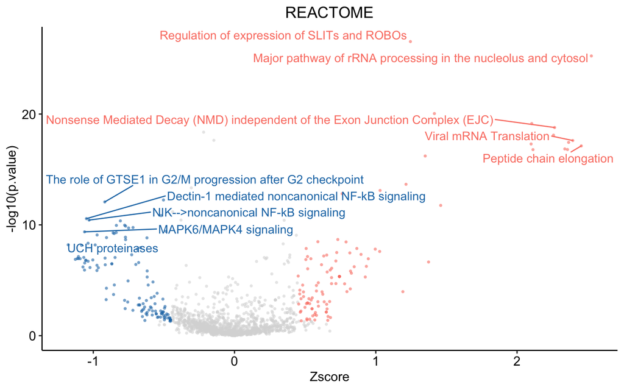

```r
res$reactome.p
```

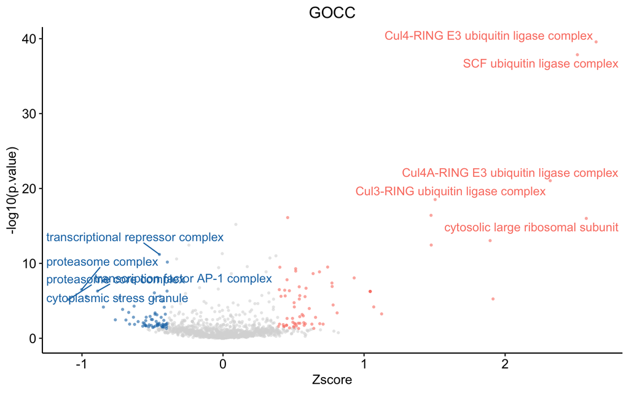

```r
res$gocc.p
```

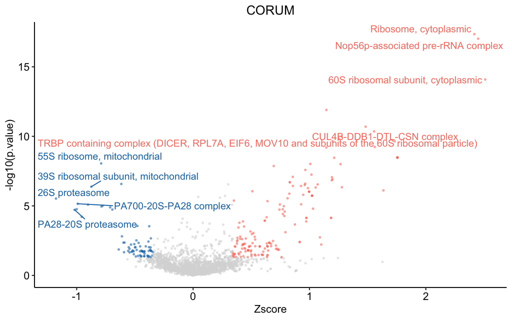

```r
res$corum.p
```